# Food at College

```r
# From your file menu (at the top of R-Studio) select:
# "Session -> Set working directory -> To source file location"
# Then play this chunk to get the data into R.
library(mosaic)
library(car)
library(DT)
library(pander)
library(readr)
library(forcats)
food <- read_csv("../../Data/food.csv") #food.csv is in the Data folder...
```

```r
# Let's take a look at the data
# View(food)
```

## Background

### Introduction-Context

In today’s day it’s becoming harder to afford to eat healthier due to cost. I want to examine if there’s a relationship between a higher income and a better diet due to healthier foods becoming more expensive and those of a lesser quality being cheaper and bought more by those with a lower income. Here’s the categories for Income as if you display them on a boxplot the chart become skewed and hard to read: 1 - less than `$`15,000  
2 - `$`15,001 to `$`30,000 3 - `$`30,001 to `$`50,000 4 - `$`50,001 to `$`70,000 5 - `$`70,001 to `$`100,000 6 - higher than `$`100,000

### Hypothesis for ANOVA

$$H_O: \text{There is no difference in income between the different diet
types.}$$

### Numerical/Graphing Summaries

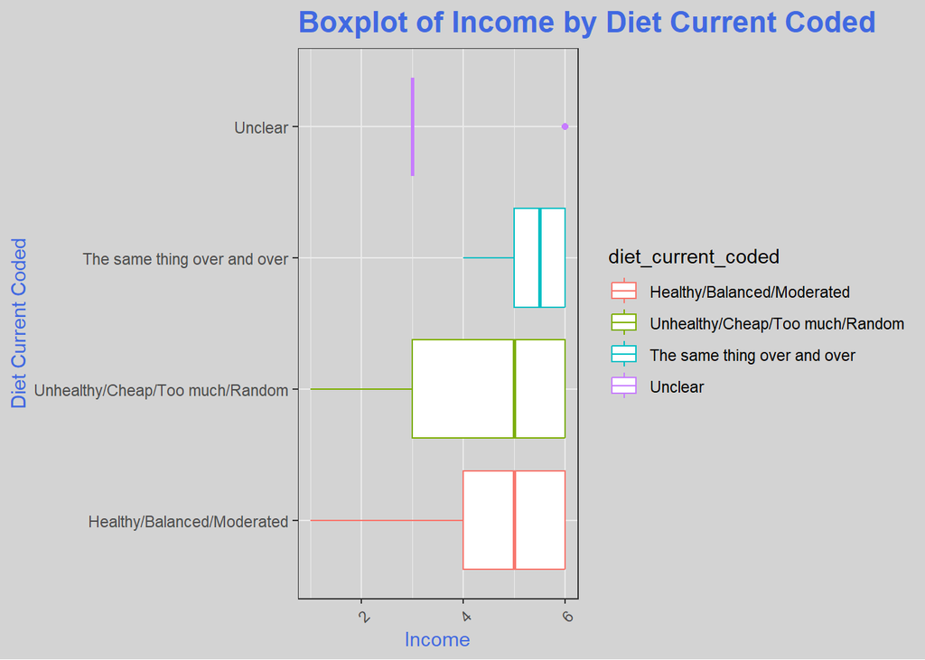

```r
#Boxplot and numerical summaries

testdata <- food %>%
  mutate(diet_current_coded = as.factor(diet_current_coded)) %>%
  filter(!is.na(income))

testdata <- testdata %>%
  mutate(diet_current_coded = fct_recode(as.factor(diet_current_coded),
                                          "Healthy/Balanced/Moderated" = "1",
                                          "Unhealthy/Cheap/Too much/Random" = "2",
                                          "The same thing over and over" = "3",
                                          "Unclear" = "4"))
# testdata <- testdata %>%
#   mutate(income = fct_recode(as.factor(income),
#                               "Less than $15,000" = "1",
#                               "$15,001 to $30,000" = "2",
#                               "$30,001 to $50,000" = "3",
#                               "$50,001 to $70,000" = "4",
#                               "$70,001 to $100,000" = "5",
#                               "Higher than $100,000" = "6"))

ggplot(testdata, aes(x = diet_current_coded, y = income, color = diet_current_coded)) +
  geom_boxplot() +
  labs(title = "Boxplot of Income by Diet Current Coded",
       x = "Diet Current Coded",
       y = "Income") +
  theme_bw() +
  theme(
    panel.background = element_rect(fill = "lightgrey", color = NA),
    plot.background = element_rect(fill = "lightgrey", color = NA),
    plot.title = element_text(color = "royalblue", face = "bold", size = 16),
    axis.title.x = element_text(color = "royalblue"),
    axis.title.y = element_text(color = "royalblue"),
    legend.background = element_rect(fill = "lightgrey"),
    axis.text.x = element_text(angle = 45, hjust = 1)
  ) +
    coord_flip()
```

```r
pander(favstats(income ~ diet_current_coded, data = testdata))
```

Table continues below

| diet_current_coded | min | Q1 | median | Q3 | max | mean | sd |
| --- | --- | --- | --- | --- | --- | --- | --- |
| Healthy/Balanced/Moderated | 1 | 4 | 5 | 6 | 6 | 4.612 | 1.426 |
| Unhealthy/Cheap/Too much/Random | 1 | 3 | 5 | 6 | 6 | 4.417 | 1.533 |
| The same thing over and over | 4 | 5 | 5.5 | 6 | 6 | 5.3 | 0.8233 |
| Unclear | 3 | 3 | 3 | 3 | 6 | 3.6 | 1.342 |

| n | missing |
| --- | --- |
| 49 | 0 |
| 60 | 0 |
| 10 | 0 |
| 5 | 0 |

### One-Way Anova

```r
# One-Way ANOVA for Sports and diet current coded


aov_sports_diet <- aov(income ~ diet_current_coded, data = testdata)
pander(summary(aov_sports_diet))
```

Analysis of Variance Model We have a p-valye of .1471 and due to our alpha of 0.05 we fail to reject the null hypothesis. According to the ANOVA test there is no difference in income between the different diet types.

|  | Df | Sum Sq | Mean Sq | F value | Pr(>F) |
| --- | --- | --- | --- | --- | --- |
| **diet_current_coded** | 3 | 11.35 | 3.785 | 1.82 | 0.1471 |
| **Residuals** | 120 | 249.5 | 2.079 | NA | NA |

### qqPlot/Requirements

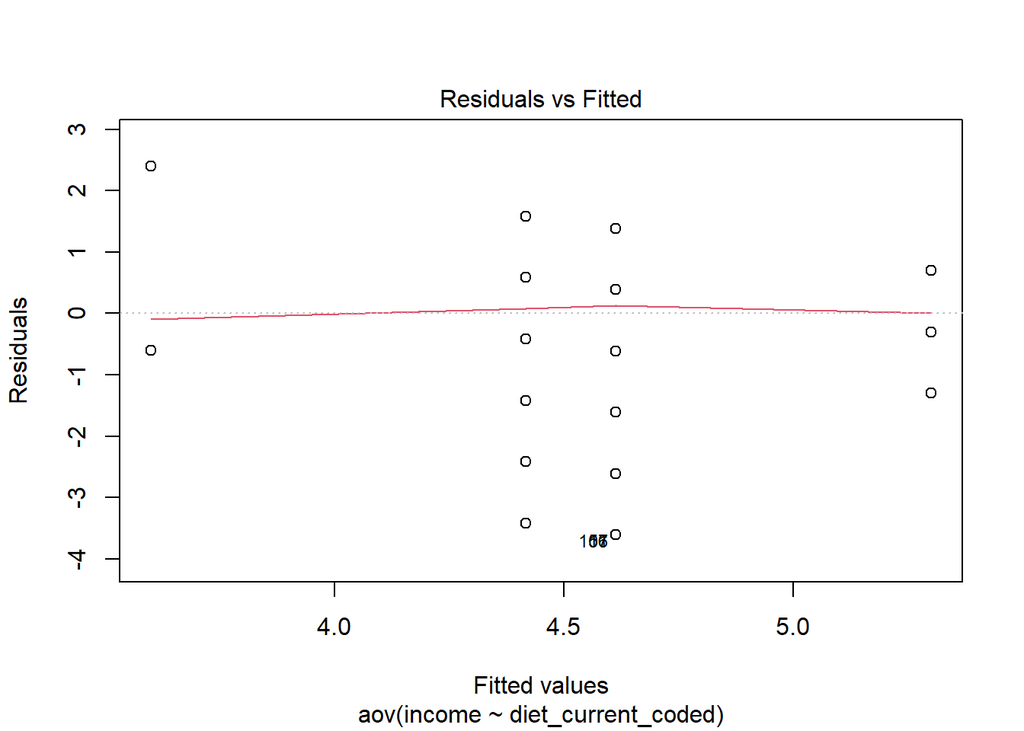

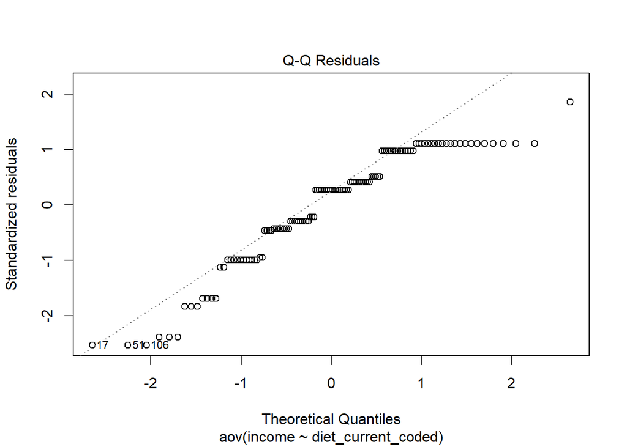

```r
# qqplot to test normality

plot(aov_sports_diet, which = 1:2)
```

We see that the requirements are met by the one-way ANOVA test for the hypothesis. But we’re gonna complete a Kruskal-Wallis test to just confirm and compare our assumptions.

### Hypothesis for KW-Test

$$H_O: \text{There is no difference in income between the different diet
types groups.}$$

$$H_A: \text{At least one diet grouping has a different income.}$$

$$a = 0.05$$

### Kruskal-Wallis Test

```r
#Kruskal-Wallis Test

pander(kruskal.test(income ~ diet_current_coded, data = testdata))
```

Kruskal-Wallis rank sum test: `income` by `diet_current_coded`

| Test statistic | df | P value |
| --- | --- | --- |
| 5.315 | 3 | 0.1501 |

### Requirements for KW-Test

We can see from prior that the requirements were already met and does not require further testing to check for normality.

### Conclusion

We can conclude from our one-way ANOVA and the Kruskal-Wallis test that we fail to reject the null hypothesis. There is no difference in income between the different diet types. We can see from our p-value that it is greater than 0.05 but it is close and could help us examine the information deeper if we wanted to know more.